# Chapter 1: Axioms of Islamic Preferences

*Formal Theory of Islamic Economics*

## 1.1 Introduction

In standard microeconomic theory, consumer behavior is derived from a set of axioms on preference relations over a consumption set $X \subseteq \mathbb{R}^L_+$. The seminal treatment in Mas-Colell, Whinston, and Green (1995) begins with binary relations satisfying completeness, transitivity, and continuity, from which utility representations are derived.

In this chapter, we develop an analogous but modified axiomatic framework for an **Islamic economic agent** — one whose preferences are shaped by the normative constraints of Islamic law (*Shariah*). We show that several standard axioms require modification, and that new axioms are needed to capture distinctly Islamic economic behavior.

The key departures from standard theory are:

1. **Restricted consumption set**: The set of permissible goods is constrained by *halal/haram* classifications before optimization begins
2. **Bounded monotonicity**: The axiom of "more is better" is modified by the prohibition of *israf* (extravagance/waste)
3. **Extended preference domain**: Preferences extend over both worldly (*dunya*) and hereafter (*akhirah*) outcomes
4. **Moderation axiom**: The principle of *wasatiyyah* (balance/moderation) introduces a preference for interior allocations

We proceed as follows. Section 1.2 establishes the Islamic consumption set. Section 1.3 develops the modified axioms. Section 1.4 provides key results on the structure of Islamic preferences. Section 1.5 illustrates these concepts computationally.

## 1.2 The Islamic Consumption Set

### 1.2.1 Standard Framework

In standard theory, the consumption set is typically $X = \mathbb{R}^L_+$, the non-negative orthant of $L$-dimensional Euclidean space, where $L$ is the number of commodities. The consumer chooses a bundle $x = (x_1, \ldots, x_L) \in X$.

### 1.2.2 The Halal Partition

In an Islamic framework, the commodity space is partitioned into permissible and impermissible goods.

**Definition 1.1** *(Halal-Haram Partition)*. Let $\mathcal{L} = \{1, \ldots, L\}$ be the set of all commodities. The *halal-haram partition* is a partition $\mathcal{L} = \mathcal{H} \cup \mathcal{H}^c$ where $\mathcal{H}$ is the set of *halal* (permissible) commodities and $\mathcal{H}^c$ is the set of *haram* (impermissible) commodities. We assume $\mathcal{H} \neq \emptyset$.

**Definition 1.2** *(Islamic Consumption Set)*. The **Islamic consumption set** is:

$$X^I = \left\{ x \in \mathbb{R}^L_+ : x_\ell = 0 \text{ for all } \ell \in \mathcal{H}^c \right\}$$

Equivalently, $X^I \cong \mathbb{R}^{|\mathcal{H}|}_+$, the non-negative orthant of the halal commodity space.

**Remark 1.1.** This is a *hard constraint* — it restricts the feasible set before any optimization. Unlike a budget constraint, which is parametric (it changes with prices and income), the halal constraint is structural and invariant to market conditions. An agent does not consume haram goods regardless of how cheap they become.

**Remark 1.2.** The partition $\mathcal{H}$ may depend on context. For instance, a commodity that is generally halal may become haram in excessive quantities (connecting to the israf axiom below). We initially treat $\mathcal{H}$ as fixed and address quantity-dependent permissibility in Section 1.3.

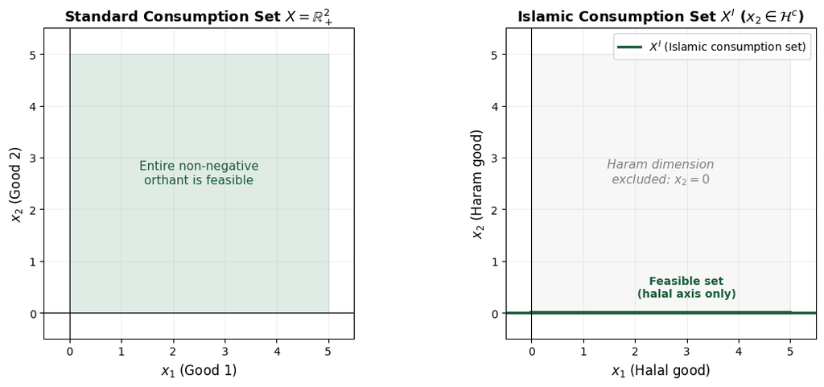

```
Figure 1.1: The Islamic consumption set restricts the feasible region to halal commodities only.
```

```python
import numpy as np
import matplotlib.pyplot as plt
import matplotlib.patches as patches

fig, axes = plt.subplots(1, 2, figsize=(12, 5))

# Standard consumption set
ax1 = axes[0]
ax1.fill_between([0, 5], [0, 0], [5, 5], alpha=0.15, color='#2d7a4f')
ax1.set_xlim(-0.5, 5.5)
ax1.set_ylim(-0.5, 5.5)
ax1.set_xlabel('$x_1$ (Good 1)', fontsize=12)
ax1.set_ylabel('$x_2$ (Good 2)', fontsize=12)
ax1.set_title('Standard Consumption Set $X = \\mathbb{R}^2_+$', fontsize=13, fontweight='bold')
ax1.axhline(y=0, color='black', linewidth=0.8)
ax1.axvline(x=0, color='black', linewidth=0.8)
ax1.annotate('Entire non-negative\northant is feasible', xy=(2.5, 2.5), fontsize=11, ha='center', color='#1a5c3a')
ax1.grid(True, alpha=0.2)
ax1.set_aspect('equal')

# Islamic consumption set (Good 2 is haram)
ax2 = axes[1]
ax2.fill_between([0, 5], [0, 0], [5, 5], alpha=0.06, color='gray')
ax2.fill_between([0, 5], [0, 0], [0, 0], alpha=0.3, color='#2d7a4f', linewidth=0)
ax2.axhline(y=0, color='#1a5c3a', linewidth=2.5, label='$X^I$ (Islamic consumption set)')
ax2.plot([0, 5], [0, 0], color='#1a5c3a', linewidth=3)
ax2.set_xlim(-0.5, 5.5)
ax2.set_ylim(-0.5, 5.5)
ax2.set_xlabel('$x_1$ (Halal good)', fontsize=12)
ax2.set_ylabel('$x_2$ (Haram good)', fontsize=12)
ax2.set_title('Islamic Consumption Set $X^I$ ($x_2 \\in \\mathcal{H}^c$)', fontsize=13, fontweight='bold')
ax2.axvline(x=0, color='black', linewidth=0.8)
ax2.annotate('Haram dimension\nexcluded: $x_2 = 0$', xy=(2.5, 2.5), fontsize=11, ha='center', color='gray', style='italic')
ax2.annotate('Feasible set\n(halal axis only)', xy=(3, 0.3), fontsize=10, ha='center', color='#1a5c3a', fontweight='bold')
ax2.legend(loc='upper right', fontsize=10)
ax2.grid(True, alpha=0.2)
ax2.set_aspect('equal')

plt.tight_layout()
plt.savefig('fig1_1_consumption_set.png', dpi=150, bbox_inches='tight', facecolor='white')
plt.show()
print("Figure 1.1: The Islamic consumption set restricts the feasible region to halal commodities only.")
```

## 1.3 Axioms of Islamic Preferences

Let $\succsim$ denote a binary (preference) relation on $X^I$. We now state the axioms governing Islamic preferences.

### 1.3.1 Standard Axioms (Retained)

**Axiom 1** *(Completeness)*. For all $x, y \in X^I$, either $x \succsim y$ or $y \succsim x$ (or both).

**Axiom 2** *(Transitivity)*. For all $x, y, z \in X^I$, if $x \succsim y$ and $y \succsim z$, then $x \succsim z$.

**Axiom 3** *(Continuity)*. For all $y \in X^I$, the upper contour set $\{x \in X^I : x \succsim y\}$ and the lower contour set $\{x \in X^I : y \succsim x\}$ are closed in $X^I$.

*These three axioms are standard and are retained without modification. By Debreu's theorem, they guarantee the existence of a continuous utility representation.*

### 1.3.2 Modified Monotonicity (The Israf Bound)

The standard monotonicity axiom states that more of any good is always (weakly) preferred. In Islamic economics, this conflicts with the prohibition of *israf* (wastefulness, extravagance):

> *"Eat and drink, but do not be extravagant. Indeed, He does not like those who are extravagant."* — Al-A'raf 7:31

We replace standard monotonicity with:

**Axiom 4** *(Bounded Monotonicity / Israf Axiom)*. There exists a **satiation bound** $\bar{x} \in X^I$ with $\bar{x} \gg 0$ such that:

(i) For all $x, y \in X^I$ with $x \leq \bar{x}$ and $y \leq \bar{x}$: if $x \geq y$ and $x \neq y$, then $x \succ y$ *(monotonicity below the bound)*

(ii) For all $x \in X^I$ with $x_\ell > \bar{x}_\ell$ for some $\ell$: $\bar{x} \succsim x$ *(the satiation bound is weakly preferred to any bundle exceeding it in any component)*

**Remark 1.3.** Part (i) preserves standard monotonicity within the permissible range. Part (ii) captures the idea that consumption beyond $\bar{x}$ constitutes *israf* and is not welfare-improving. The bound $\bar{x}$ may be interpreted as the level of consumption consistent with *wasatiyyah* (moderation).

### 1.3.3 The Moderation Axiom (Wasatiyyah)

The Quran describes the Muslim community as an *ummatan wasatan* — a community of the middle way (Al-Baqarah 2:143). We formalize this as a preference for balanced consumption:

**Axiom 5** *(Wasatiyyah / Strict Convexity within the Israf Bound)*. For all $x, y \in X^I$ with $x \leq \bar{x}$, $y \leq \bar{x}$, and $x \neq y$: if $x \sim y$ (indifference), then for any $\alpha \in (0, 1)$:

$$\alpha x + (1 - \alpha) y \succ x$$

provided $\alpha x + (1-\alpha)y \leq \bar{x}$.

*This is strict convexity restricted to the permissible consumption region. It formalizes the preference for moderation: a balanced mix of goods is strictly preferred to extremes.*

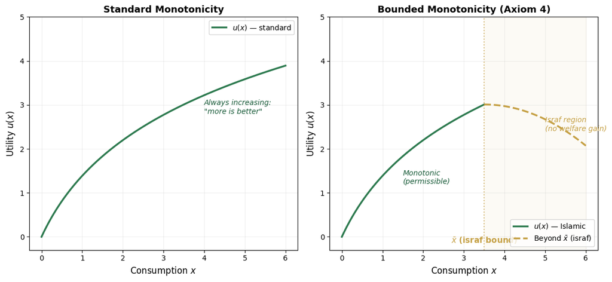

```
Figure 1.2: Bounded monotonicity — utility increases up to the israf bound x̄, then flattens or decreases.
```

```python
import numpy as np
import matplotlib.pyplot as plt

fig, axes = plt.subplots(1, 2, figsize=(12, 5.5))

# Standard monotonicity (utility always increasing)
ax1 = axes[0]
x = np.linspace(0, 6, 200)
u_standard = np.log(1 + x) * 2  # always increasing
ax1.plot(x, u_standard, color='#2d7a4f', linewidth=2.5, label='$u(x)$ — standard')
ax1.set_xlabel('Consumption $x$', fontsize=12)
ax1.set_ylabel('Utility $u(x)$', fontsize=12)
ax1.set_title('Standard Monotonicity', fontsize=13, fontweight='bold')
ax1.annotate('Always increasing:\n"more is better"', xy=(4, 2.8), fontsize=10, color='#1a5c3a', style='italic')
ax1.legend(fontsize=10)
ax1.grid(True, alpha=0.2)
ax1.set_xlim(-0.3, 6.3)
ax1.set_ylim(-0.3, 5)

# Bounded monotonicity (Islamic — israf bound)
ax2 = axes[1]
x_below = np.linspace(0, 3.5, 150)
x_above = np.linspace(3.5, 6, 100)
u_below = np.log(1 + x_below) * 2
u_peak = u_below[-1]
u_above = u_peak - 0.15 * (x_above - 3.5)**2  # decreasing beyond bound

ax2.plot(x_below, u_below, color='#2d7a4f', linewidth=2.5, label='$u(x)$ — Islamic')
ax2.plot(x_above, u_above, color='#c5a044', linewidth=2.5, linestyle='--', label='Beyond $\\bar{x}$ (israf)')
ax2.axvline(x=3.5, color='#c5a044', linewidth=1.5, linestyle=':', alpha=0.7)
ax2.annotate('$\\bar{x}$ (israf bound)', xy=(3.5, -0.15), fontsize=11, ha='center', color='#c5a044', fontweight='bold')
ax2.annotate('Monotonic\n(permissible)', xy=(1.5, 1.2), fontsize=10, color='#1a5c3a', style='italic')
ax2.annotate('Israf region\n(no welfare gain)', xy=(5, u_peak - 0.6), fontsize=10, color='#c5a044', style='italic')
ax2.fill_between(x_above, -0.5, 5, alpha=0.05, color='#c5a044')

ax2.set_xlabel('Consumption $x$', fontsize=12)
ax2.set_ylabel('Utility $u(x)$', fontsize=12)
ax2.set_title('Bounded Monotonicity (Axiom 4)', fontsize=13, fontweight='bold')
ax2.legend(fontsize=10, loc='lower right')
ax2.grid(True, alpha=0.2)
ax2.set_xlim(-0.3, 6.3)
ax2.set_ylim(-0.3, 5)

plt.tight_layout()
plt.savefig('fig1_2_bounded_monotonicity.png', dpi=150, bbox_inches='tight', facecolor='white')
plt.show()
print("Figure 1.2: Bounded monotonicity — utility increases up to the israf bound x̄, then flattens or decreases.")
```

## 1.4 Key Results

### 1.4.1 Existence of a Utility Representation

**Proposition 1.1** *(Existence of Islamic Utility Function)*. If $\succsim$ satisfies Axioms 1–3 on $X^I$, then there exists a continuous function $u^I : X^I \to \mathbb{R}$ such that for all $x, y \in X^I$:

$$x \succsim y \iff u^I(x) \geq u^I(y)$$

*Proof.* Since $X^I \cong \mathbb{R}^{|\mathcal{H}|}_+$ is a connected, separable topological space and $\succsim$ is complete, transitive, and continuous (Axioms 1–3), the result follows directly from Debreu's Representation Theorem (Debreu, 1954). $\square$

**Remark 1.4.** The halal constraint does not affect the existence of a utility representation — it merely restricts the domain. The interesting departures come from Axioms 4 and 5.

### 1.4.2 Properties of the Islamic Utility Function

**Proposition 1.2** *(Properties under Axioms 4–5)*. Let $u^I : X^I \to \mathbb{R}$ represent $\succsim$ satisfying Axioms 1–5. Then:

(i) $u^I$ is strictly increasing on $[0, \bar{x}] \cap X^I$ *(monotonicity in the permissible region)*

(ii) $u^I$ attains a maximum at $\bar{x}$ *(the satiation point)*

(iii) $u^I$ is strictly quasi-concave on $[0, \bar{x}] \cap X^I$ *(preference for moderation)*

*Proof sketch.*  
(i) follows from Axiom 4(i) — within the bound, standard monotonicity applies.  
(ii) follows from Axiom 4(ii) — no bundle beyond $\bar{x}$ is strictly preferred to $\bar{x}$.  
(iii) follows from Axiom 5 (strict convexity within the bound) by standard arguments. $\square$

### 1.4.3 Comparison with Standard Theory

**Proposition 1.3** *(Islamic Preferences as Constrained Standard Preferences)*. Let $\succsim^S$ be a standard preference relation on $\mathbb{R}^L_+$ satisfying completeness, transitivity, continuity, strict monotonicity, and strict convexity. Define the **Islamic restriction** $\succsim^I$ as the restriction of $\succsim^S$ to $X^I \cap [0, \bar{x}]$. Then $\succsim^I$ satisfies Axioms 1–5 (with the obvious modification that the domain is compact).

*This proposition shows that Islamic preferences can be viewed as standard preferences restricted to a feasible set that is both type-constrained (halal) and quantity-constrained (israf). The Islamic framework does not require fundamentally different preference structures — it requires different constraints on the domain over which standard-type preferences operate.*

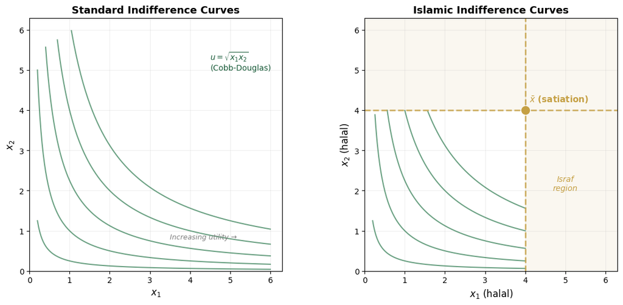

```
Figure 1.3: Islamic indifference curves are truncated at the israf bound x̄.
```

```python
import numpy as np
import matplotlib.pyplot as plt

fig, axes = plt.subplots(1, 2, figsize=(12, 5.5))

# Standard indifference curves
ax1 = axes[0]
x1 = np.linspace(0.2, 6, 200)
for u_level in [0.5, 1.0, 1.5, 2.0, 2.5]:
    x2 = (u_level**2) / x1  # u = sqrt(x1*x2)
    mask = x2 <= 6
    ax1.plot(x1[mask], x2[mask], color='#2d7a4f', linewidth=1.5, alpha=0.7)
ax1.set_xlabel('$x_1$', fontsize=12)
ax1.set_ylabel('$x_2$', fontsize=12)
ax1.set_title('Standard Indifference Curves', fontsize=13, fontweight='bold')
ax1.annotate('$u = \\sqrt{x_1 x_2}$\n(Cobb-Douglas)', xy=(4.5, 5), fontsize=10, color='#1a5c3a')
ax1.annotate('Increasing utility →', xy=(3.5, 0.8), fontsize=9, color='gray', style='italic')
ax1.set_xlim(0, 6.3)
ax1.set_ylim(0, 6.3)
ax1.grid(True, alpha=0.2)
ax1.set_aspect('equal')

# Islamic indifference curves with israf bound
ax2 = axes[1]
x_bar = 4.0
x1 = np.linspace(0.2, x_bar, 200)
for u_level in [0.5, 1.0, 1.5, 2.0, 2.5]:
    x2 = (u_level**2) / x1
    mask = (x2 <= x_bar) & (x2 > 0)
    ax2.plot(x1[mask], x2[mask], color='#2d7a4f', linewidth=1.5, alpha=0.7)

# Israf bound region
ax2.axvline(x=x_bar, color='#c5a044', linewidth=2, linestyle='--', alpha=0.8)
ax2.axhline(y=x_bar, color='#c5a044', linewidth=2, linestyle='--', alpha=0.8)
ax2.fill_between([x_bar, 6.3], [0, 0], [6.3, 6.3], alpha=0.08, color='#c5a044')
ax2.fill_between([0, x_bar], [x_bar, x_bar], [6.3, 6.3], alpha=0.08, color='#c5a044')

# Satiation point
ax2.plot(x_bar, x_bar, 'o', color='#c5a044', markersize=10, zorder=5)
ax2.annotate('$\\bar{x}$ (satiation)', xy=(x_bar + 0.1, x_bar + 0.2), fontsize=11, color='#c5a044', fontweight='bold')
ax2.annotate('Israf\nregion', xy=(5, 2), fontsize=10, color='#c5a044', style='italic', ha='center')

ax2.set_xlabel('$x_1$ (halal)', fontsize=12)
ax2.set_ylabel('$x_2$ (halal)', fontsize=12)
ax2.set_title('Islamic Indifference Curves', fontsize=13, fontweight='bold')
ax2.set_xlim(0, 6.3)
ax2.set_ylim(0, 6.3)
ax2.grid(True, alpha=0.2)
ax2.set_aspect('equal')

plt.tight_layout()
plt.savefig('fig1_3_indifference_curves.png', dpi=150, bbox_inches='tight', facecolor='white')
plt.show()
print("Figure 1.3: Islamic indifference curves are truncated at the israf bound x̄.")
```

## 1.5 Computational Example: The Islamic Cobb-Douglas Agent

To make these ideas concrete, consider an agent with the following **Islamic Cobb-Douglas** utility function:

$$u^I(x_1, x_2) = \begin{cases} x_1^\alpha x_2^{1-\alpha} & \text{if } x_1 \leq \bar{x}_1 \text{ and } x_2 \leq \bar{x}_2 \\ \bar{x}_1^\alpha \bar{x}_2^{1-\alpha} & \text{otherwise} \end{cases}$$

where $\alpha \in (0,1)$ and $\bar{x} = (\bar{x}_1, \bar{x}_2)$ is the israf bound. This function satisfies Axioms 1–5 on $X^I$.

We now solve the consumer's problem: maximize $u^I$ subject to the budget constraint $p_1 x_1 + p_2 x_2 \leq w$ and the Islamic constraints $x \in X^I$, $x \leq \bar{x}$.

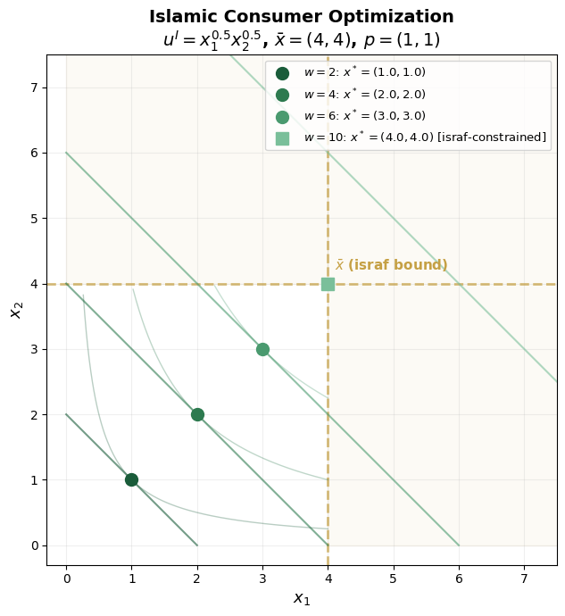

```
Figure 1.4: As wealth increases, the Islamic consumer hits the israf bound — additional wealth does not increase consumption.
At w=10, the standard optimum would be (5, 5), but the Islamic optimum is (4, 4).
The 'excess' wealth w - p·x̄ = 10 - 8 = 2 is available for zakat, sadaqah, or waqf.
```

```python
import numpy as np
import matplotlib.pyplot as plt

# Parameters
alpha = 0.5
x_bar = np.array([4.0, 4.0])  # israf bound
p = np.array([1.0, 1.0])       # prices
w_values = [2, 4, 6, 10]       # different wealth levels

fig, ax = plt.subplots(1, 1, figsize=(8, 7))

# Plot israf bound
ax.axvline(x=x_bar[0], color='#c5a044', linewidth=2, linestyle='--', alpha=0.7)
ax.axhline(y=x_bar[1], color='#c5a044', linewidth=2, linestyle='--', alpha=0.7)
ax.fill_between([x_bar[0], 8], [0, 0], [8, 8], alpha=0.05, color='#c5a044')
ax.fill_between([0, x_bar[0]], [x_bar[1], x_bar[1]], [8, 8], alpha=0.05, color='#c5a044')

colors = ['#1a5c3a', '#2d7a4f', '#4a9a6f', '#7abf9a']
optimal_points = []

for i, w in enumerate(w_values):
    # Budget line
    x1_budget = np.linspace(0, w/p[0], 200)
    x2_budget = (w - p[0]*x1_budget) / p[1]
    ax.plot(x1_budget, x2_budget, color=colors[i], linewidth=1.5, alpha=0.6)

    # Standard Cobb-Douglas optimal: x1* = alpha*w/p1, x2* = (1-alpha)*w/p2
    x1_star = alpha * w / p[0]
    x2_star = (1 - alpha) * w / p[1]

    # Islamic constraint: clip to israf bound
    x1_islamic = min(x1_star, x_bar[0])
    x2_islamic = min(x2_star, x_bar[1])

    # Check if standard solution exceeds bound
    if x1_star > x_bar[0] or x2_star > x_bar[1]:
        label = f'$w={w}$: $x^*=({x1_islamic:.1f}, {x2_islamic:.1f})$ [israf-constrained]'
        marker = 's'
    else:
        label = f'$w={w}$: $x^*=({x1_islamic:.1f}, {x2_islamic:.1f})$'
        marker = 'o'

    ax.plot(x1_islamic, x2_islamic, marker, color=colors[i], markersize=10, zorder=5, label=label)
    optimal_points.append((x1_islamic, x2_islamic))

# Indifference curves through optimal points
x1_ic = np.linspace(0.1, 7, 300)
for pt, color in zip(optimal_points, colors):
    if pt[0] > 0 and pt[1] > 0:
        u_level = pt[0]**alpha * pt[1]**(1-alpha)
        x2_ic = (u_level / x1_ic**alpha)**(1/(1-alpha))
        mask = (x2_ic <= 7) & (x2_ic > 0) & (x1_ic <= x_bar[0]) & (x2_ic <= x_bar[1])
        ax.plot(x1_ic[mask], x2_ic[mask], color=color, linewidth=1, alpha=0.3, linestyle='-')

ax.annotate('$\\bar{x}$ (israf bound)', xy=(x_bar[0] + 0.1, x_bar[1] + 0.2), fontsize=11, color='#c5a044', fontweight='bold')
ax.set_xlabel('$x_1$', fontsize=13)
ax.set_ylabel('$x_2$', fontsize=13)
ax.set_title('Islamic Consumer Optimization\n$u^I = x_1^{0.5} x_2^{0.5}$, $\\bar{x} = (4, 4)$, $p = (1, 1)$', fontsize=14, fontweight='bold')
ax.legend(fontsize=9.5, loc='upper right')
ax.set_xlim(-0.3, 7.5)
ax.set_ylim(-0.3, 7.5)
ax.grid(True, alpha=0.2)
ax.set_aspect('equal')

plt.tight_layout()
plt.savefig('fig1_4_optimization.png', dpi=150, bbox_inches='tight', facecolor='white')
plt.show()
print("Figure 1.4: As wealth increases, the Islamic consumer hits the israf bound — additional wealth does not increase consumption.")
print("At w=10, the standard optimum would be (5, 5), but the Islamic optimum is (4, 4).")
print("The 'excess' wealth w - p·x̄ = 10 - 8 = 2 is available for zakat, sadaqah, or waqf.")
```

### 1.5.1 The Zakat Residual

**Observation 1.1.** When wealth $w$ exceeds $p \cdot \bar{x}$, the Islamic consumer has a **surplus**:

$$s = w - p \cdot \bar{x}$$

This surplus cannot increase personal utility (by Axiom 4). It is precisely this surplus that becomes available for *zakat* (obligatory charity), *sadaqah* (voluntary charity), and *waqf* (endowment).

In Chapter 2, we will show that when utility is extended to include an *akhirah* component, this surplus is **optimally allocated** to charitable channels — providing a formal microfoundation for the zakat obligation.

> The israf axiom does not merely prevent waste — it creates the economic basis for redistribution.

## 1.6 Summary

This chapter established the axiomatic foundations for Islamic consumer preferences:

| Axiom | Name | Standard Theory | Islamic Modification |
| --- | --- | --- | --- |
| 1 | Completeness | Retained | No change |
| 2 | Transitivity | Retained | No change |
| 3 | Continuity | Retained | No change |
| 4 | Monotonicity | Strict monotonicity | Bounded by israf: monotone only up to $\bar{x}$ |
| 5 | Convexity | Strict convexity | Wasatiyyah: strict convexity within $[0, \bar{x}]$ |
| — | Domain | $X = \mathbb{R}^L_+$ | $X^I$: halal commodities only |

**Key results:**

- **Proposition 1.1**: A continuous utility representation exists (Debreu's theorem applies on $X^I$)
- **Proposition 1.2**: The Islamic utility function is increasing up to $\bar{x}$, maximal at $\bar{x}$, and strictly quasi-concave
- **Proposition 1.3**: Islamic preferences can be viewed as standard preferences on a constrained domain

**Next: Chapter 2** will develop the **two-component utility representation** (dunya + akhirah), providing the formal basis for understanding zakat and charitable giving as rational economic behavior.

### References

- Debreu, G. (1954). "Representation of a preference ordering by a numerical function." *Decision Processes*, 3, 159–165.
- Mas-Colell, A., Whinston, M. D., & Green, J. R. (1995). *Microeconomic Theory*. Oxford University Press.
- Al-Ghazali, Abu Hamid. *Ihya Ulum al-Din* (The Revival of the Religious Sciences).
- Chapra, M. U. (1992). *Islam and the Economic Challenge*. The Islamic Foundation.
- Kahf, M. (2003). "Islamic Economics: Notes on Definition and Methodology." *Review of Islamic Economics*, 13, 23–47.